# code_for_covid_gr_clinics

# PART I: Summary Statistics

**Plot histogram of data by group and look at summary statistics**

- Plot overall

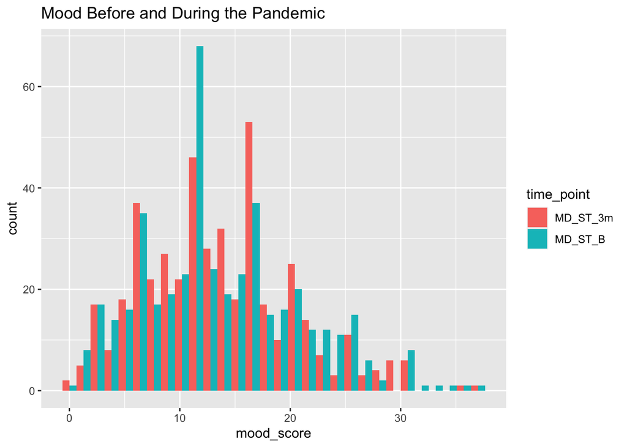

```r
covid_gr_clinics_train_long %>%
  ggplot(aes(x=mood_score,fill=time_point)) +
  geom_histogram(position="dodge") +
   ggtitle("Mood Before and During the Pandemic")
```

```r
#results = "hide"
```

- Summary Statistics overall

```r
  summary_stats <- covid_gr_clinics_train_long %>%
  group_by(time_point)

  #have to use awkward :: syntax because of some package overlap problem
  summary_stats <- dplyr::summarise(summary_stats, n = n(), median =
                                             median(mood_score, na.rm = T),
            mean = mean(mood_score, na.rm =T), sd = sd(mood_score, na.rm =T),
            quantile_25 = quantile(mood_score, probs = c(0.25)),
            quantile_75 = quantile(mood_score, probs = c(0.75)))

summary_stats
```

```
## # A tibble: 2 x 7
##   time_point     n median  mean    sd quantile_25 quantile_75
##   <chr>      <int>  <int> <dbl> <dbl>       <dbl>       <dbl>
## 1 MD_ST_3m     443     13  13.5  6.74           9          17
## 2 MD_ST_B      443     13  13.7  7.14           9          18
```

This suggests that there is no difference overall

- Plot by age

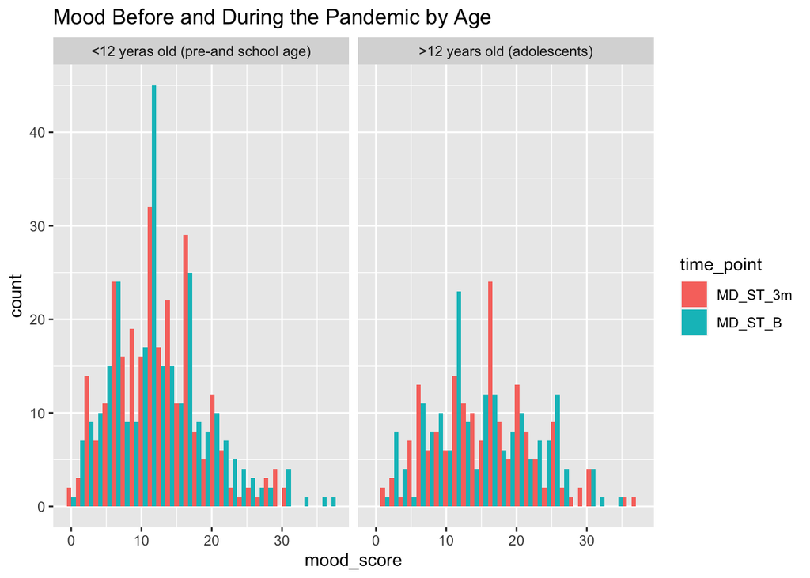

```r
covid_gr_clinics_train_long %>%
  ggplot(aes(x=mood_score,fill=time_point)) +
  geom_histogram(position="dodge") +
  facet_wrap(~age_D)+
   ggtitle("Mood Before and During the Pandemic by Age")
```

```r
#results = "hide"
```

- Summary Stats by Age

```r
  summary_stats_by_age <- covid_gr_clinics_train_long %>%
  group_by(time_point, age_D)

  #have to use awkward :: syntax because of some package overlap problem
  summary_stats_by_age <- dplyr::summarise(summary_stats_by_age, n = n(), median =
                                             median(mood_score, na.rm = T),
            mean = mean(mood_score, na.rm =T), sd = sd(mood_score, na.rm =T),
            quantile_25 = quantile(mood_score, probs = c(0.25)),
            quantile_75 = quantile(mood_score, probs = c(0.75)))

summary_stats_by_age
```

```
## # A tibble: 4 x 8
## # Groups:   time_point [2]
##   time_point age_D                  n median  mean    sd quantile_25 quantile_75
##   <chr>      <chr>              <int>  <dbl> <dbl> <dbl>       <dbl>       <dbl>
## 1 MD_ST_3m   <12 yeras old (pr…   269     12  12.3  6.24           8          16
## 2 MD_ST_3m   >12 years old (ad…   174     15  15.4  7.06          10          20
## 3 MD_ST_B    <12 yeras old (pr…   269     12  12.7  6.85           8          17
## 4 MD_ST_B    >12 years old (ad…   174     15  15.2  7.34          10          21
```

Two things seem obvious. - the distributions are not too bad. - based on the means and medians, there is little evidence of a difference before and after the pandemic.

- Plot by Site

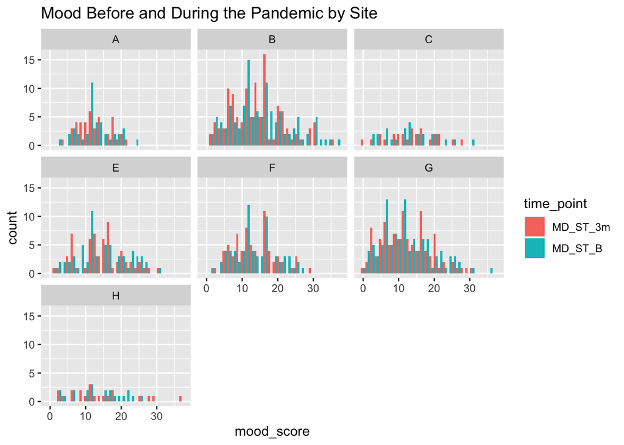

```r
covid_gr_clinics_train_long %>%
  ggplot(aes(x=mood_score,fill=time_point)) +
  geom_histogram(position="dodge") +
  facet_wrap(~site) +
  ggtitle("Mood Before and During the Pandemic by Site")
```

```r
#results = "hide"
```

- Summary Stats by Site

```r
  summary_stats_by_site <- covid_gr_clinics_train_long %>%
  group_by(site, time_point)

  #have to use awkward :: syntax because of some package overlap problem
  summary_stats_by_site <- dplyr::summarise(summary_stats_by_site, n = n(), median =
                                             median(mood_score, na.rm = T),
            mean = mean(mood_score, na.rm =T), sd = sd(mood_score, na.rm =T),
            quantile_25 = quantile(mood_score, probs = c(0.25)),
            quantile_75 = quantile(mood_score, probs = c(0.75)))

summary_stats_by_site
```

```
## # A tibble: 14 x 8
## # Groups:   site [7]
##    site  time_point     n median  mean    sd quantile_25 quantile_75
##    <chr> <chr>      <int>  <dbl> <dbl> <dbl>       <dbl>       <dbl>
##  1 A     MD_ST_3m      41     12  12.6  4.50        9           16
##  2 A     MD_ST_B       41     12  12.6  4.72       10           15
##  3 B     MD_ST_3m     117     14  14.2  7.40        8           18
##  4 B     MD_ST_B      117     14  15.1  8.10       10           20
##  5 C     MD_ST_3m      27     14  13.7  6.89        9.5         18
##  6 C     MD_ST_B       27     13  13.2  7.13        7.5         17.5
##  7 E     MD_ST_3m      62     15  14.7  6.42       12           18.8
##  8 E     MD_ST_B       62     13  14.6  7.15        9.25        20.8
##  9 F     MD_ST_3m      68     13  13.5  5.79        9           17
## 10 F     MD_ST_B       68     13  13.6  6.06        9.75        17
## 11 G     MD_ST_3m     107     11  12.3  6.80        7           17
## 12 G     MD_ST_B      107     11  12.3  7.27        7           17
## 13 H     MD_ST_3m      21     12  14.2  9.18        9           18
## 14 H     MD_ST_B       21     15  13.7  7.08       10           19
```

- Sites C and H have very few participants
- Overall, there is very little increase though. The medians and means are nearly identical.
- Plot by diagnosis

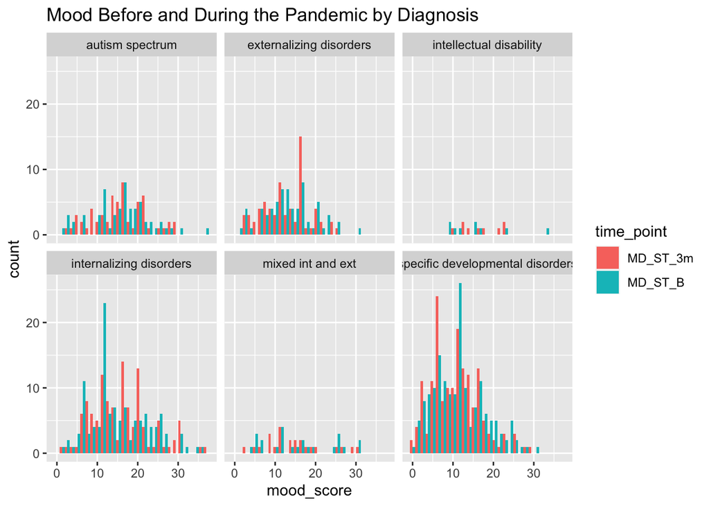

```r
covid_gr_clinics_train_long %>%
  ggplot(aes(x=mood_score,fill=time_point)) +
  geom_histogram(position="dodge") +
  facet_wrap(~Diagnosis_FINAL_groups_revised)+
   ggtitle("Mood Before and During the Pandemic by Diagnosis")
```

- Summary Stats by Diagnosis

```r
  summary_stats_by_diagnosis <- covid_gr_clinics_train_long %>%
  group_by(Diagnosis_FINAL_groups_revised, time_point)

  #have to use awkward :: syntax because of some package overlap problem
  summary_stats_by_diagnosis <- dplyr::summarise(summary_stats_by_diagnosis, n = n(), median =
                                             median(mood_score, na.rm = T),
            mean = mean(mood_score, na.rm =T), sd = sd(mood_score, na.rm =T),
            quantile_25 = quantile(mood_score, probs = c(0.25)),
            quantile_75 = quantile(mood_score, probs = c(0.75)))

summary_stats_by_diagnosis
```

```
## # A tibble: 12 x 8
## # Groups:   Diagnosis_FINAL_groups_revised [6]
##    Diagnosis_FINAL_… time_point     n median  mean    sd quantile_25 quantile_75
##    <chr>             <chr>      <int>  <dbl> <dbl> <dbl>       <dbl>       <dbl>
##  1 autism spectrum   MD_ST_3m      59   15    15.7  6.64       11           21
##  2 autism spectrum   MD_ST_B       59   16    15.8  7.30       11           20
##  3 externalizing di… MD_ST_3m      67   13    12.9  5.57        8.5         16
##  4 externalizing di… MD_ST_B       67   13    13.4  6.05        9.5         17
##  5 intellectual dis… MD_ST_3m       9   17    17    4.85       13           22
##  6 intellectual dis… MD_ST_B        9   15    15.9  7.83       10           17
##  7 internalizing di… MD_ST_3m     118   16    16.1  7.22       11           20
##  8 internalizing di… MD_ST_B      118   14    15.3  7.44       11           21
##  9 mixed int and ext MD_ST_3m      24   14    14.8  7.39        9.75        18.2
## 10 mixed int and ext MD_ST_B       24   14.5  15.7  8.65        9           24.2
## 11 specific develop… MD_ST_3m     166   10.5  10.9  5.81        7           14
## 12 specific develop… MD_ST_B      166   11    11.5  6.44        6.25        15.8
```

The diagnosis of mixed int/ext and ID are too few to consider. Again, there does not seem to be much variability by diagnosis either, with the possible exception of externalizing. Also, it is interesting that the variability seems higher–the SD seems to be higher during the pandemic

# Part II: Inferential Statistics

**Question 1: Has mood state changed before and during the pandemic defined as change from 3mo to BL**

- Q1 spaghetti plot overall

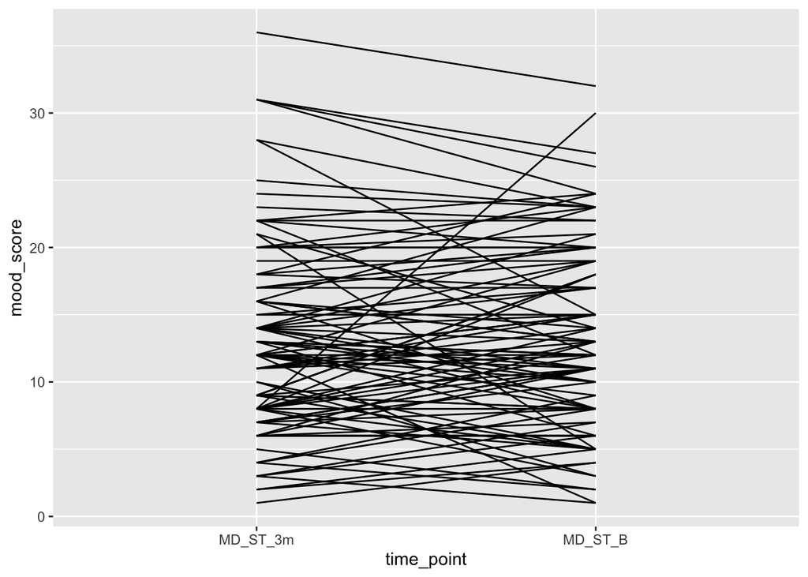

```r
# to make spaghetti plot visualisation better, subsample a set of observations
set.seed(1234) # for reproducibility
subsample_covid_gr_clinics_train_long  <- covid_gr_clinics_train_long[covid_gr_clinics_train_long$id %in%  sample(unique(covid_gr_clinics_train$id), 100),] # this is the sampling command


spaghetti_1 <- subsample_covid_gr_clinics_train_long %>%
 # filter(Subject <= 100) %>%
    ggplot(aes(x = time_point, y = mood_score,
             group = as.factor(id))) +
  geom_line()#+
   #facet_grid( age_D~.)
  #stat_summary( aes (group=1),geom = "point", fun = mean,
   #                         shape = 17, size = 3, color = "red")
spaghetti_1
```

This does not suggest that there is an increase in scores

- Q1 boxplot of differences overall

```r
library(hrbrthemes)
library(viridis)
```

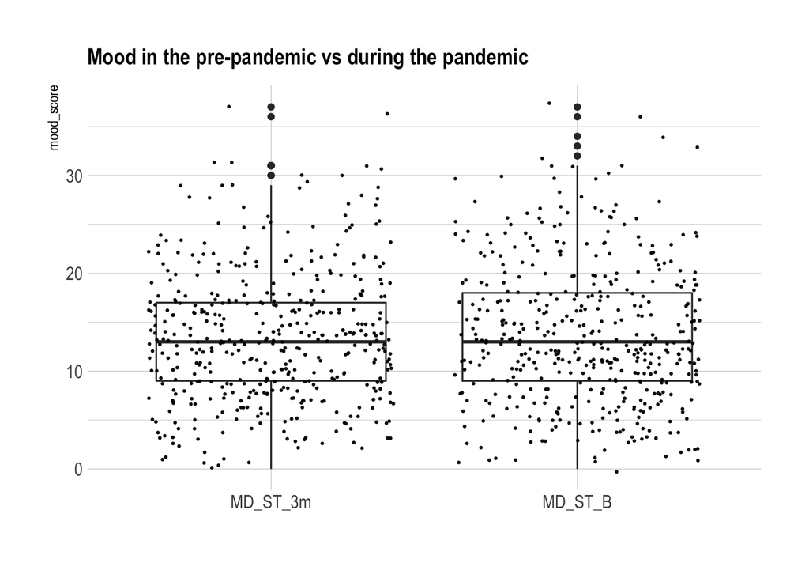

```r
covid_gr_clinics_train_long %>%
  ggplot( aes(x=time_point, y=mood_score)) +
    geom_boxplot() +
    scale_fill_viridis(discrete = TRUE, alpha=0.6) +
    geom_jitter(color="black", size=0.4, alpha=0.9) +
    theme_ipsum() +
    theme(
      legend.position="right",
      plot.title = element_text(size=14)
    ) +
    ggtitle("Mood in the pre-pandemic vs during the pandemic") +
    xlab("")
```

- Q1 A bootstrap paired t-test of the differences

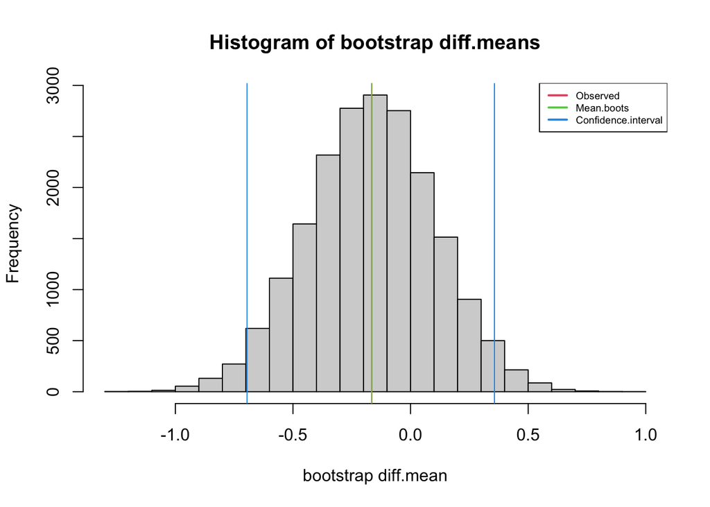

```
##
##
##  RESULTS OF PERCENTILE BOOTSTRAP FOR DIFF.MEAN
##
##     SUMMARY                           Pop.1                          Pop.2   n
##  STATISTICS covid_gr_clinics_train$MD_ST_3m covid_gr_clinics_train$MD_ST_B 443
##  Statistic   Observed
##  diff.mean -0.1647856
##
##  BOOTSTRAP Replications       Mean        SE      Bias Percent.bias
##    SUMMARY        20000 -0.1657183 0.2695966 -0.000933        0.566
##
##  CONFIDENCE Level      Type Confidence.interval
##    INTERVAL   95% two-sided   (-0.6953, 0.3567)
```

```r
library(wBoot)
set.seed(1234)
boot.paired.per(covid_gr_clinics_train$MD_ST_3m, covid_gr_clinics_train$MD_ST_B,  null.hyp = NULL,
                 R = 20000)
```

This shows that there are no differences overall.

- An even nicer way of showing that there is no difference

```r
library(dabestr)
```

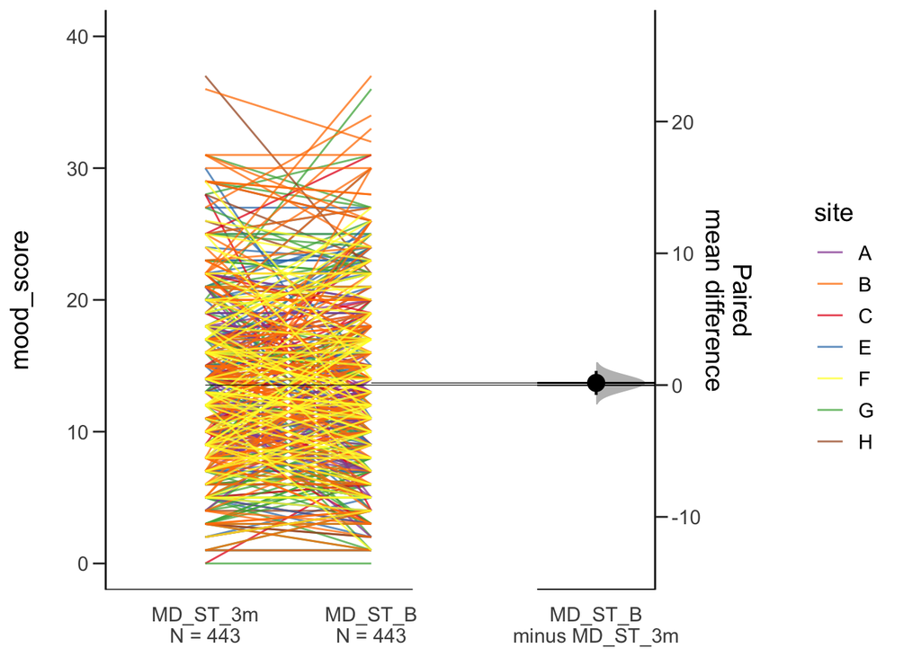

```r
set.seed(1234)
bootstrap <- dabest(covid_gr_clinics_train_long,
                    time_point,
                    mood_score,
                   idx = c("MD_ST_3m", "MD_ST_B"),
                    paired = TRUE, id.col = id)

bootstrap_diff <- mean_diff(bootstrap)

plot(bootstrap_diff, color.column = site, rawplot.ylim = c(0, 40), effsize.ylim = c(-10,10))
```

**Question 2: Has mood state changed before and during the pandemic defined as change from 3mo to BL, but differently by age group?**

- This question is best answered by modeling the interaction between time and age group
- This can be done as an ANCOVA or, preferably for reasons of flexibility, as a linear mixed effects model. Because we only have two time points, we cannot model both intercept and slope but can model random intercepts only. The fixed effects of such a model should be equivalent to what we get in the ANCOVA.
- Note, in the first instance we are not going to model site, to keep things simple.
- Q2: Visual Inspection

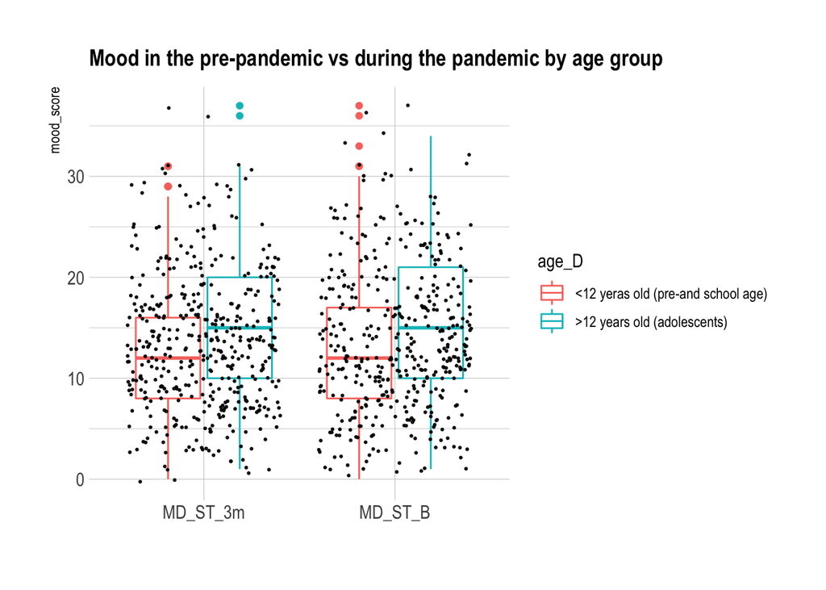

```r
library(hrbrthemes)
library(viridis)
covid_gr_clinics_train_long %>%
  ggplot( aes(x=time_point, y=mood_score, color = age_D)) +
    geom_boxplot() +
    scale_fill_viridis(discrete = TRUE, alpha=0.6) +
    geom_jitter(color="black", size=0.4, alpha=0.9) +
    theme_ipsum() +
    theme(
      legend.position="right",
      plot.title = element_text(size=14)
    ) +
    ggtitle("Mood in the pre-pandemic vs during the pandemic by age group") +
    xlab("")
```

- there seem to be outliers for the pandemic in the under 12. - no other clear differences.

- Q2: Linear mixed effects model of age by time interaction

```r
lme_with_interaction <- lmer(mood_score ~ time_point*age_D + (1 | id), data = covid_gr_clinics_train_long)
coefs <- data.frame(coef(summary(lme_with_interaction)))
coefs$p.z <- 2 * (1 - pnorm(abs(coefs$t.value)))
coefs
```

```
##                                                      Estimate Std..Error
## (Intercept)                                        12.3085502  0.4154848
## time_pointMD_ST_B                                   0.4052045  0.3450191
## age_D>12 years old (adolescents)                    3.1224843  0.6629524
## time_pointMD_ST_B:age_D>12 years old (adolescents) -0.6121010  0.5505166
##                                                      t.value          p.z
## (Intercept)                                        29.624551 0.000000e+00
## time_pointMD_ST_B                                   1.174441 2.402186e-01
## age_D>12 years old (adolescents)                    4.709967 2.477565e-06
## time_pointMD_ST_B:age_D>12 years old (adolescents) -1.111867 2.661955e-01
```

There is no significant effect of the interaction term

- Q2: To illustrate the point, I also run this as an ANCOVA

```r
mood_model_with_age_interaction <- aov(mood_score ~  time_point*age_D,data = covid_gr_clinics_train_long)
summary.lm(mood_model_with_age_interaction)
```

```
##
## Call:
## aov(formula = mood_score ~ time_point * age_D, data = covid_gr_clinics_train_long)
##
## Residuals:
##     Min      1Q  Median      3Q     Max
## -14.431  -5.096  -0.431   4.286  24.286
##
## Coefficients:
##                                                    Estimate Std. Error t value
## (Intercept)                                         12.3086     0.4155  29.625
## time_pointMD_ST_B                                    0.4052     0.5876   0.690
## age_D>12 years old (adolescents)                     3.1225     0.6630   4.710
## time_pointMD_ST_B:age_D>12 years old (adolescents)  -0.6121     0.9376  -0.653
##                                                    Pr(>|t|)
## (Intercept)                                         < 2e-16 ***
## time_pointMD_ST_B                                     0.491
## age_D>12 years old (adolescents)                   2.88e-06 ***
## time_pointMD_ST_B:age_D>12 years old (adolescents)    0.514
## ---
## Signif. codes:  0 '***' 0.001 '**' 0.01 '*' 0.05 '.' 0.1 ' ' 1
##
## Residual standard error: 6.814 on 882 degrees of freedom
## Multiple R-squared:  0.0399, Adjusted R-squared:  0.03663
## F-statistic: 12.22 on 3 and 882 DF,  p-value: 7.743e-08
```

The results are very similar

- Q2: now re-run LME with exclusion of outliers. First step, decide on value of outlier

```r
# in order to decide what is an outlier use the following
quantile(covid_gr_clinics_train$MD_ST_B, 0.975)
```

```
## 97.5%
##    30
```

```r
quantile(covid_gr_clinics_train$MD_ST_3m, 0.975)
```

```
## 97.5%
##    29
```

This indicates that a value of 30 for baseline and 29 for pre-pandemic is appropriate

- Q2: now re-run LME with exclusion of outliers. First step, decide on value of outlier

```r
# create new dataset with excluded outliers
covid_gr_clinics_train_no_outliers <- covid_gr_clinics_train %>%
  filter(covid_gr_clinics_train$MD_ST_B <30 & covid_gr_clinics_train$MD_ST_3m <29)

# Now turn it into long
covid_gr_clinics_train_no_outliers_long <- gather(covid_gr_clinics_train_no_outliers, time_point, mood_score, MD_ST_B, MD_ST_3m)

lme_with_interaction <- lmer(mood_score ~ time_point*age_D + (1 | id), data = covid_gr_clinics_train_no_outliers_long)
coefs <- data.frame(coef(summary(lme_with_interaction)))
coefs$p.z <- 2 * (1 - pnorm(abs(coefs$t.value)))
coefs
```

```
##                                                      Estimate Std..Error
## (Intercept)                                        11.7276265  0.3735596
## time_pointMD_ST_B                                   0.2140078  0.3308822
## age_D>12 years old (adolescents)                    2.7106451  0.6007716
## time_pointMD_ST_B:age_D>12 years old (adolescents) -0.2942547  0.5321363
##                                                       t.value          p.z
## (Intercept)                                        31.3942582 0.000000e+00
## time_pointMD_ST_B                                   0.6467794 5.177747e-01
## age_D>12 years old (adolescents)                    4.5119395 6.423752e-06
## time_pointMD_ST_B:age_D>12 years old (adolescents) -0.5529686 5.802849e-01
```

This too shows that once the outliers are excluded, there is no significant interaction term.

- Q2

# Comments so far

- The interaction term seems week.
- It is probably even less important once outliers have been taken into account

# Additional Analyses to assess inclusion of the interaction term

- Q2: Linear mixed effects model **with bootstrap** in order to assess the value of including an interaction term into the model
- we should consider three models.
- lme_time with time as the only predictor
- lme_time_age with time and age as main effects
- lme_time_age_interaction with time and age as main effects and their interaction
- Q2: The base model, lme_time

```r
set.seed(1234)
require(MuMIn) # this package allows you to get R-squareds (r.squaredGLMM, below)


# this is a function to obtain the r-squared out of the bootstrapped LMEs
rsq <- function(formula, data, indices) {
  d <- data[indices,]
  model.fit <- lmer(mood_score ~ time_point  + (1 | id), data = d)
  fit.r.squared <- r.squaredGLMM(model.fit)
  return(fit.r.squared)
}
# now run the bootstrapped lme
set.seed(1234)
lme_time <- boot(data=covid_gr_clinics_train_long, statistic=rsq,
                R=1000, formula=mood_score ~ time_point  + (1 | id))
# now extract the vector with the R-squareds
R2_lme_time <- lme_time[2]
R2_lme_time <- R2_lme_time$t[,1]
```

- Q2: The next plausible model, lme_time_age

```r
rsq <- function(formula, data, indices) {
  d <- data[indices,]
  model.fit <- lmer(mood_score ~ time_point  + age_D + (1 | id), data = d)
  fit.r.squared <- r.squaredGLMM(model.fit)
  return(fit.r.squared)
}
# now run the bootstrapped lme
set.seed(1234)
lme_time_age <- boot(data=covid_gr_clinics_train_long, statistic=rsq,
                R=1000, formula=mood_score ~ time_point  + age_D + (1 | id))

# now extract the vector with the R-squareds
R2_lme_time_age <- lme_time_age[2]
R2_lme_time_age <- R2_lme_time_age$t[,1]
```

- Q2: The interaction model

```r
rsq <- function(formula, data, indices) {
  d <- data[indices,]
  model.fit <- lmer(mood_score ~ time_point*age_D + (1 | id), data = d)
  fit.r.squared <- r.squaredGLMM(model.fit)
  return(fit.r.squared)
}
# now run the bootstrapped lme
set.seed(1234)
lme_time_age_interaction <- boot(data=covid_gr_clinics_train_long, statistic=rsq,
                R=1000, formula=mood_score ~ time_point*age_D + (1 | id))

# now extract the vector with the R-squareds
R2_lme_time_age_interaction <- lme_time_age_interaction[2]
R2_lme_time_age_interaction <- R2_lme_time_age_interaction$t[,1]
```

- Q2: test the difference between the R-squared of the three models

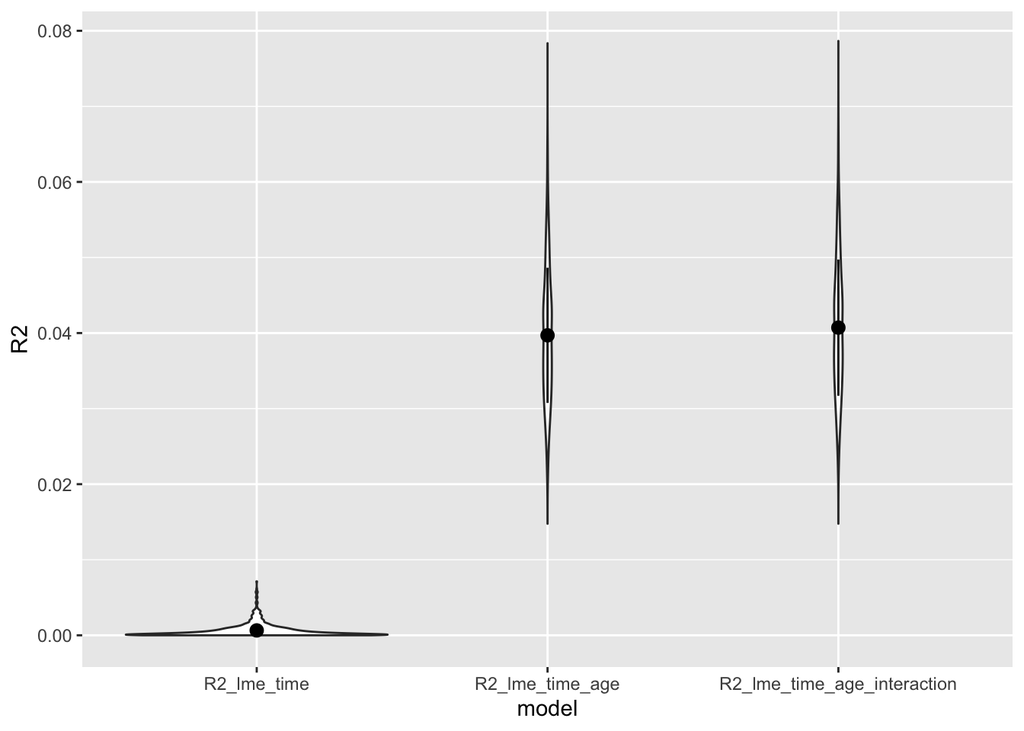

```r
# first bind the vectors from each of the models above into a dataframe
df_r_R2_lmes <-as.data.frame(cbind(R2_lme_time,R2_lme_time_age,R2_lme_time_age_interaction))

# create a long dataframe for ease of plotting
df_r_R2_lmes_long<- gather(df_r_R2_lmes, model, R2, R2_lme_time, R2_lme_time_age, R2_lme_time_age_interaction)

# plot r-squared as violin plot
# first you need to create a data summary function to feed into the violin plot
data_summary <- function(x) {
   mu <- mean(x)
   sigma1 <- mu-sd(x)
   sigma2 <- mu+sd(x)
   return(c(y=mu,ymin=sigma1,ymax=sigma2))
}

# here is the violin plot
ggplot(data=df_r_R2_lmes_long, aes(x=model, y=R2)) +
geom_violin() + stat_summary(fun.data=data_summary)
```

- Q2: Compare the R2s of the three models. I am doing this in a parametric and a non parametric way

```r
#now test the difference between the two R_squareds using an anova
R2_anova <- aov(R2 ~ model, data = df_r_R2_lmes_long)
# summary(R2_anova)
TukeyHSD(R2_anova)
```

```
##   Tukey multiple comparisons of means
##     95% family-wise confidence level
##
## Fit: aov(formula = R2 ~ model, data = df_r_R2_lmes_long)
##
## $model
##                                                    diff          lwr
## R2_lme_time_age-R2_lme_time                 0.039052243 0.0382812651
## R2_lme_time_age_interaction-R2_lme_time     0.040071594 0.0393006167
## R2_lme_time_age_interaction-R2_lme_time_age 0.001019352 0.0002483738
##                                                     upr     p adj
## R2_lme_time_age-R2_lme_time                 0.039823221 0.0000000
## R2_lme_time_age_interaction-R2_lme_time     0.040842572 0.0000000
## R2_lme_time_age_interaction-R2_lme_time_age 0.001790329 0.0055379
```

```r
# as the data seem to be slightly skewed particularly for the time-only model, use NP test
kruskal.test(R2 ~ model, data = df_r_R2_lmes_long)
```

```
##
##  Kruskal-Wallis rank sum test
##
## data:  R2 by model
## Kruskal-Wallis chi-squared = 2002.2, df = 2, p-value < 2.2e-16
```

```r
# and follow up with


wilcox.test(df_r_R2_lmes$R2_lme_time_age, df_r_R2_lmes$R2_lme_time_age_interaction)
```

```
##
##  Wilcoxon rank sum test with continuity correction
##
## data:  df_r_R2_lmes$R2_lme_time_age and df_r_R2_lmes$R2_lme_time_age_interaction
## W = 467426, p-value = 0.01165
## alternative hypothesis: true location shift is not equal to 0
```

On the basis of this analysis, the interaction model seems to be preferred.